# analysis

## Importing modules

First, we need to import modules that we're going to need. Here, I may use numpy, pandas, and matplotlib.

```python
# "as" is useful so that we can just call type "np" to use this module instead of typing numpy
import numpy as np
import pandas as pd
import matplotlib.pyplot as plt
# This allows us to plot things in the notebook directly.
%matplotlib inline
```

## Importing data

There are many ways to import data. However, for data analysis, importing data as pandas's DataFrame structure is probably most useful. It's pretty good at importing the columns into correct data types. I use read_csv command available from pandas module. Data has already been cleaned to remove any error messages, fix typos in the data, and make data type consistent for each column. Identifiable personal information also have been removed.

```python
# Make sure data.csv file is in the same folder
data = pd.read_csv('data.csv')
```

```python
# We can now look at the data that's been imported.  .head() function on a pd.DataFrame shows first five rows.
data.head()
```

|  | id | alumni | birthday | city | state | zipcode | life_stage | grad_year | first_sunday_id | second_sunday_id | ... | sunday_id | commit_life | family_group_interest | member_interest | serving_interest | baptism_interest | alpha_interest | growth_module_interest | service_site | sunday |
| --- | --- | --- | --- | --- | --- | --- | --- | --- | --- | --- | --- | --- | --- | --- | --- | --- | --- | --- | --- | --- | --- |
| 0 | 1 | 1.0 | 1989 | Boston | MA | 2215 | young_adult | 2012 | NaN | NaN | ... | 3 | NaN | NaN | NaN | NaN | NaN | NaN | NaN | NaN | 1/15/12 |
| 1 | 1 | 1.0 | 1989 | Boston | MA | 2215 | young_adult | 2012 | NaN | NaN | ... | 4 | NaN | NaN | NaN | NaN | NaN | NaN | NaN | NaN | 1/22/12 |
| 2 | 1 | 1.0 | 1989 | Boston | MA | 2215 | young_adult | 2012 | NaN | NaN | ... | 5 | NaN | NaN | NaN | NaN | NaN | NaN | NaN | NaN | 2/5/12 |
| 3 | 1 | 1.0 | 1989 | Boston | MA | 2215 | young_adult | 2012 | NaN | NaN | ... | 7 | NaN | NaN | NaN | NaN | NaN | NaN | NaN | NaN | 2/19/12 |
| 4 | 1 | 1.0 | 1989 | Boston | MA | 2215 | young_adult | 2012 | NaN | NaN | ... | 8 | NaN | NaN | NaN | NaN | NaN | NaN | NaN | NaN | 2/26/12 |

5 rows × 21 columns

## Visualize

Now that we have imported the data succesfully, we can visualize some simple data.

#### Attendance by Sunday

First, let's look at number of connection cards filled out per Sunday. For this visualization, we use barplot, because we're counting by distinct states (Sundays).

```python
'''
I choose to use sunday_id column instead of sunday column,
because sunday_id column is an array of numbers that increase chronologically,
whereas sunday column is an array of strings that loops every year (1/15/2016 is before 3/2/2012).
Then I create a list of strings that correspond to the sunday_id list.
'''
sundays = data.sunday_id
sundays_unique = sorted(set(sundays))
sundays_string = [list(data.sunday[data.sunday_id==i])[0] for i in sundays_unique]
```

```python
count_sundays = [sum(sundays == i) for i in sundays_unique]
```

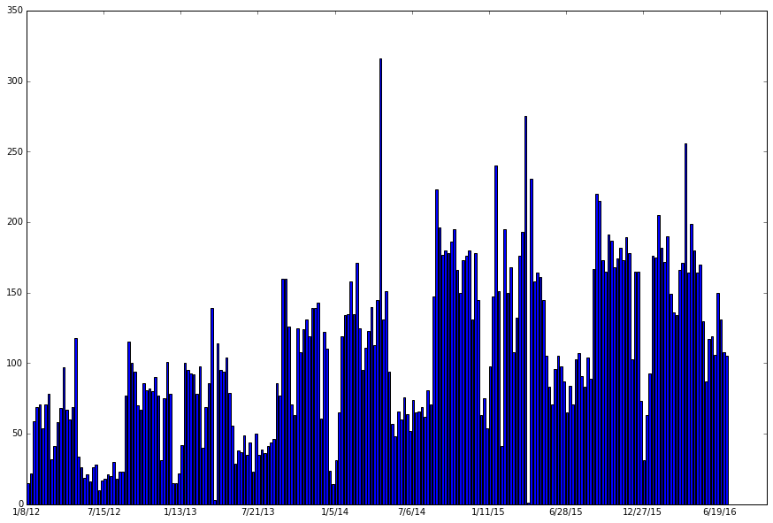

```python
plt.figure(figsize=(15,10))
plt.bar(range(len(sundays_unique)),count_sundays)
ax = plt.gca()
ax.set_xticks(np.arange(0,237,26))
ax.set_xticklabels(np.array(sundays_string)[np.arange(0,237,26)])
plt.show; # the semicolon supresses the annoying message <function matplotlib.pyplot.show>
```

You can see the slowly increasing attendance until 2015. You can see the deep wide dips during summer every year, the deep narrow dips during winter every year. In the spring, there's typically a single high peak, which probably corresponds to Easter service. There's nothing knew here; it's showing us what we would've expected. But it's still nice to see in a plot.

#### Attendance by member

Now, let's look at attendance by members. Here, we'll categorize members by how many times they have attended. To visualize this data, we'll use histogram, since we're looking at frequency distribution.

We'll write a function to create histogram with a maximum count. I don't think we need to distinguish between people who attended 30 times or 50 times or 100 times. So we'll look at 1 through N-1 days individually, then N or more days.

```python
ids = data.id
```

```python
def hist(array,maximum=0):
    unique = sorted(set(array))
    if maximum>0:
        return [min(sum(array==i),maximum) for i in unique]
    else:
        return [sum(array==i) for i in unique]
```

```python
hist_ids30 = hist(ids,maximum=30)
```

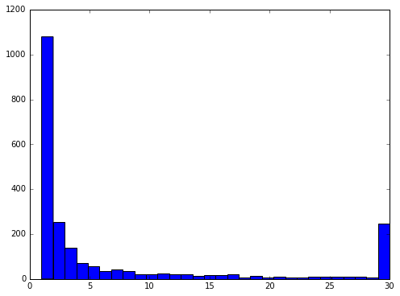

```python
plt.figure(figsize=(8,6))
plt.hist(hist_ids30,bins=30)
plt.show;
```

There's a lot of 1-time comers, then continues to decrease significantly to higher attendances. We can zoom in a little more and make the max 20. (Feel free to zoom in even more)

```python
hist_ids20 = hist(ids,maximum=20)
```

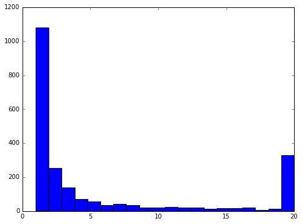

```python
plt.figure(figsize=(8,6))
plt.hist(hist_ids20,bins=20)
plt.show;
```

## Create new columns

It's sometimes useful to create new columns that's easier to work with. For example, I want to divide the Sundays into different years (Sept to Aug)---let's name them 0 (Jan 2012 - Aug 2012) to 4 (Sept 2015 to June 2016).

```python
def year(datestr):
    mo, _, yr = datestr.split('/')
    return (int(yr)-12+int(int(mo)/9))
```

```python
data['year'] = np.array([year(i) for i in data['sunday']])
```

## Creating new DataFrame

We can continue to work with the DataFrame we have above, but it's a little annoying when you're trying to do studies about unique members. I'm going to make a new DataFrame with each row representing a unique member, copying over the member-specific information and adding some additional columns.

```python
columns_to_copy = ['id','birthday','city','state','zipcode','life_stage','grad_year','first_sunday_id','second_sunday_id','how_hear']
data_member = data[columns_to_copy][0:1]
for i in data.index[1:]:
    if data.id[i-1] != data.id[i]:
        data_member = data_member.append(data[columns_to_copy][i:i+1],ignore_index=True)
```

```python
data_member['attendance'] = np.array([sum(data.id==i) for i in data_member.id])
```

```python
data_member.head()
```

|  | id | birthday | city | state | zipcode | life_stage | grad_year | first_sunday_id | second_sunday_id | how_hear | attendance |
| --- | --- | --- | --- | --- | --- | --- | --- | --- | --- | --- | --- |
| 0 | 1 | 1989 | Boston | MA | 2215 | young_adult | 2012 | NaN | NaN | Other | 49 |
| 1 | 2 | 1993 | Brookline | MA | 2446 | grad | 2015 | NaN | NaN | Other | 93 |
| 2 | 3 | 1974 | Allston | MA | 2134 | grad | 2012 | NaN | NaN | Other | 9 |
| 3 | 6 | 0 | San Francisco | CA | 94116 | grad | 2014 | NaN | NaN | Other | 7 |
| 4 | 8 | 1992 | NY | NY | 10016 | grad | 2014 | NaN | NaN | Other | 41 |

#### Life stage

We can see if attendance looks different for different life stages. First, it's important to see how many people are in each life stage.

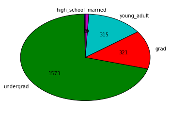

```python
life_stage = [x for x in list(set(data_member.life_stage)) if str(x) != 'nan']
# This gives us ['young_adult', 'married', 'high_school', 'grad', 'undergrad']
# Let's manually order it, since there's no way of automatically ordering it logically.
life_stage = ['high_school','undergrad','grad','young_adult','married']
life_stage_numbers = []
for i in life_stage:
    life_stage_numbers.append(sum(data_member.life_stage == i))
plt.pie(life_stage_numbers, labels=life_stage, startangle=90,
       autopct = lambda p: '{:.0f}'.format(p * len(data_member.life_stage) / 100));
```

We can do many different analysis, but let's just do the simplest thing here at look at average attendance by each group. Of course, this is probably an unfair comparison, as there are probably a lot of 1's in the undergraduate population as they tend to church hop in big groups in the beginning of every school year.

```
[('high_school', 1.2), ('undergrad', 8.796958174904942), ('grad', 17.063432835820894), ('young_adult', 25.988593155893536), ('married', 11.0)]
```

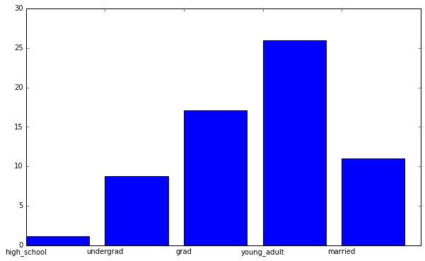

```python
life_stage_attendance = [data_member.attendance[data_member.life_stage==x].mean() for x in life_stage]
print(list(zip(life_stage,life_stage_attendance)))

plt.figure(figsize=(10,6))
plt.bar(range(len(life_stage)),life_stage_attendance)
ax = plt.gca()
ax.set_xticklabels(life_stage)
plt.show;
```

#### Final remarks

This was made as an instructional guide, and I did not really dive deep (as I need to focus on my PhD requirements at the moment...). I hope it was helpful. If you want to work more on it, please let me know.